# SU_25_River_Rockfish_Proj_V0.7

```r
ggsave(filename = "data-images/hct_ambient_boxplot.pdf", plot = hct_ambient_boxplot, device = "pdf")
ggsave(filename = "data-images/hct_ambient_boxplot.png", plot = hct_ambient_boxplot, device = "png")
```

Hct Parametric Assessment: Data Distribution

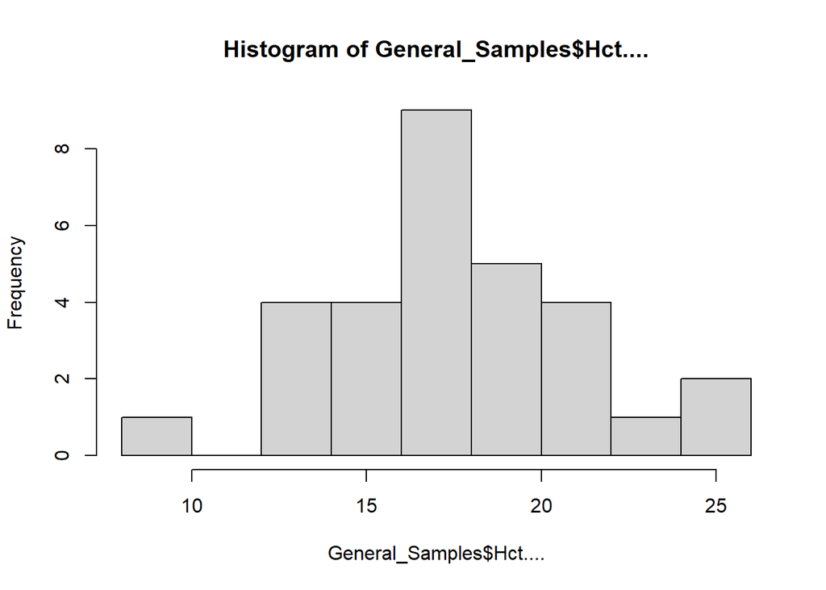

```r
# hct
# Parametric Assumptions

# Data Distribution

# Frequency Histograms
hist(General_Samples$Hct....)
```

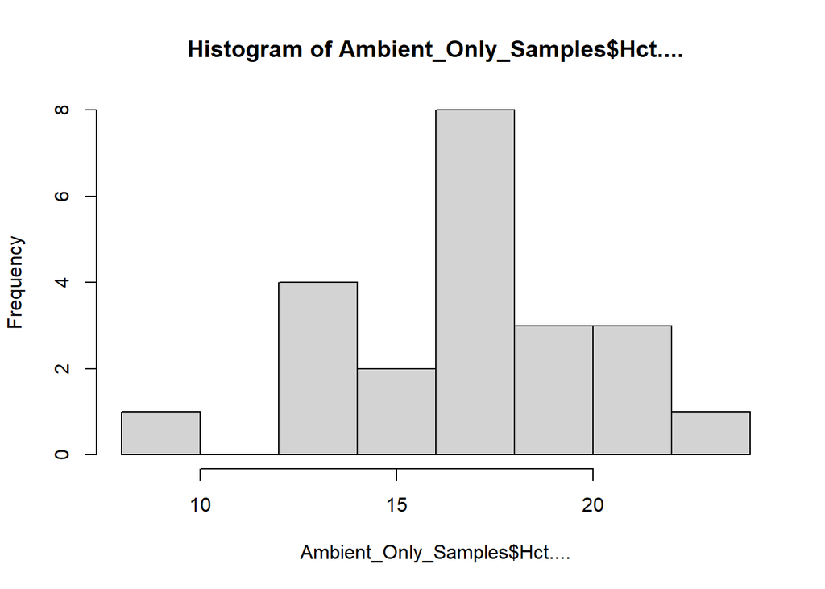

```r
hist(Ambient_Only_Samples$Hct....)
```

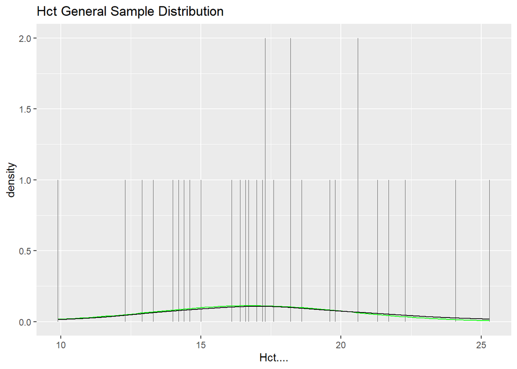

```r
# Density Histogram

# Density vs normality curve histograms
# Notes: Maybe set geom_density(alpha = 0.5)?

General_Samples %>%
  ggplot(aes(x = Hct....)) +
  geom_histogram(binwidth = 0.01) +
  stat_function(fun = dnorm, args = c(mean = mean(Ambient_Only_Samples$Hct....), sd = sd(General_Samples$Hct....)), col = "green") +
  geom_density(col = "black") +
  labs (title = "Hct General Sample Distribution")
```

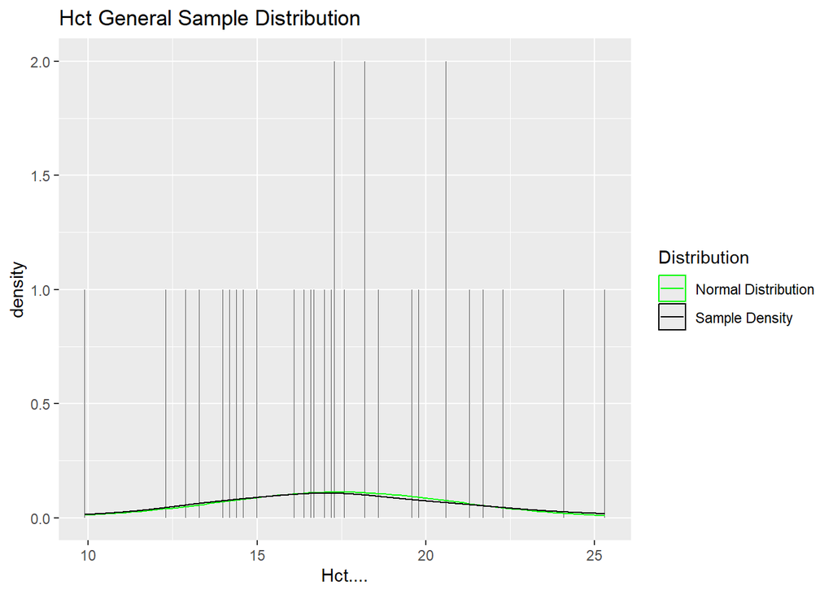

```r
# With legend label
General_Samples %>%
  ggplot(aes(x = Hct....)) +
  geom_histogram(binwidth = 0.01) +
  stat_function(fun = dnorm, args = c(mean = mean(General_Samples$Hct....), sd = sd(General_Samples$Hct....)), aes(col = "Normal Distribution"), show.legend = TRUE) +
  geom_density(aes(col = "Sample Density"), show.legend = TRUE) +
  labs(title = "Hct General Sample Distribution") +
  scale_color_manual("Distribution", values = c("Normal Distribution" = "green", "Sample Density" = "black"))
```

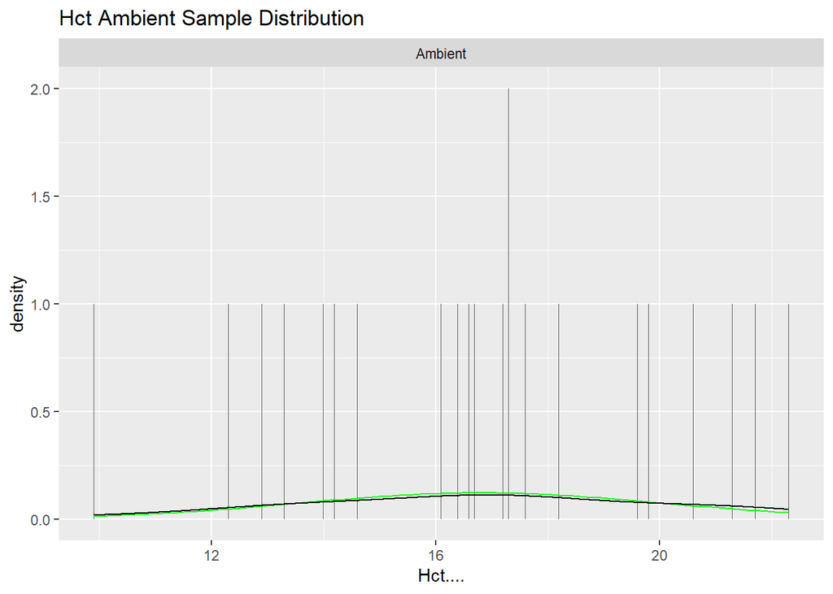

```r
Ambient_Only_Samples %>%
  ggplot(aes(x = Hct....)) +
  geom_histogram(binwidth = 0.01) +
  stat_function(fun = dnorm, args = c(mean = mean(Ambient_Only_Samples$Hct....), sd = sd(Ambient_Only_Samples$Hct....)), col = "green") +
  geom_density(col = "black") +
  facet_grid(~ Ambient.Or.OAH) +
  labs (title = "Hct Ambient Sample Distribution")
```

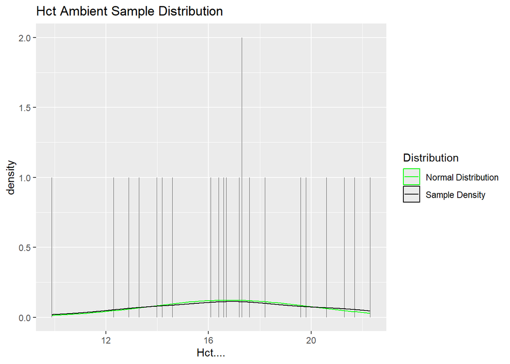

```r
# With legend label
Ambient_Only_Samples %>%
  ggplot(aes(x = Hct....)) +
  geom_histogram(binwidth = 0.01) +
  stat_function(fun = dnorm, args = c(mean = mean(Ambient_Only_Samples$Hct....), sd = sd(Ambient_Only_Samples$Hct....)), aes(col = "Normal Distribution"), show.legend = TRUE) +
  geom_density(aes(col = "Sample Density"), show.legend = TRUE) +
  labs(title = "Hct Ambient Sample Distribution") +
  scale_color_manual("Distribution", values = c("Normal Distribution" = "green", "Sample Density" = "black"))
```

Review of Data Distribution (Data normally distributed?)

General data:

Ambient data:

Hct Parametric Assessment General Normality Residual QQplot

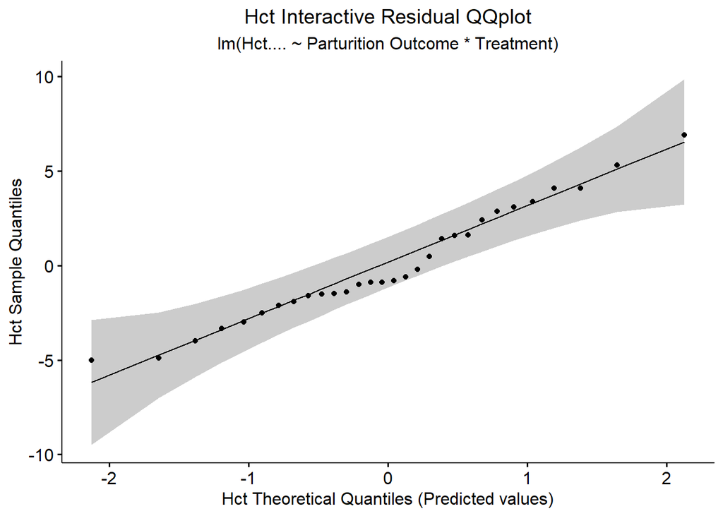

```r
# hct
# Parametric Assumptions:

# Assessing Normality
# Normality Plots
# Note: If data is non-normal considering applying transformation

# lm model of general data
hct_lm_int <- lm(Hct.... ~ Pregnant.Or.Atresia * Ambient.Or.OAH, data = General_Samples)

# View all residual plots
#plot(hct_lm_int)

hct_res_int_qqplot <- ggqqplot(residuals(hct_lm_int)) +
labs(title = "Hct Interactive Residual QQplot",
     subtitle = "lm(Hct.... ~ Parturition Outcome * Treatment)",
                               x = "Hct Theoretical Quantiles (Predicted values)",
                               y = "Hct Sample Quantiles") +
  theme(plot.title = element_text(hjust = 0.5),
        plot.subtitle = element_text(hjust = 0.5))
print(hct_res_int_qqplot)
```

Review of Residual QQplot (normality conditions met?)

General data:

Hct Parametric Assessment Ambient Normality Residual QQplot

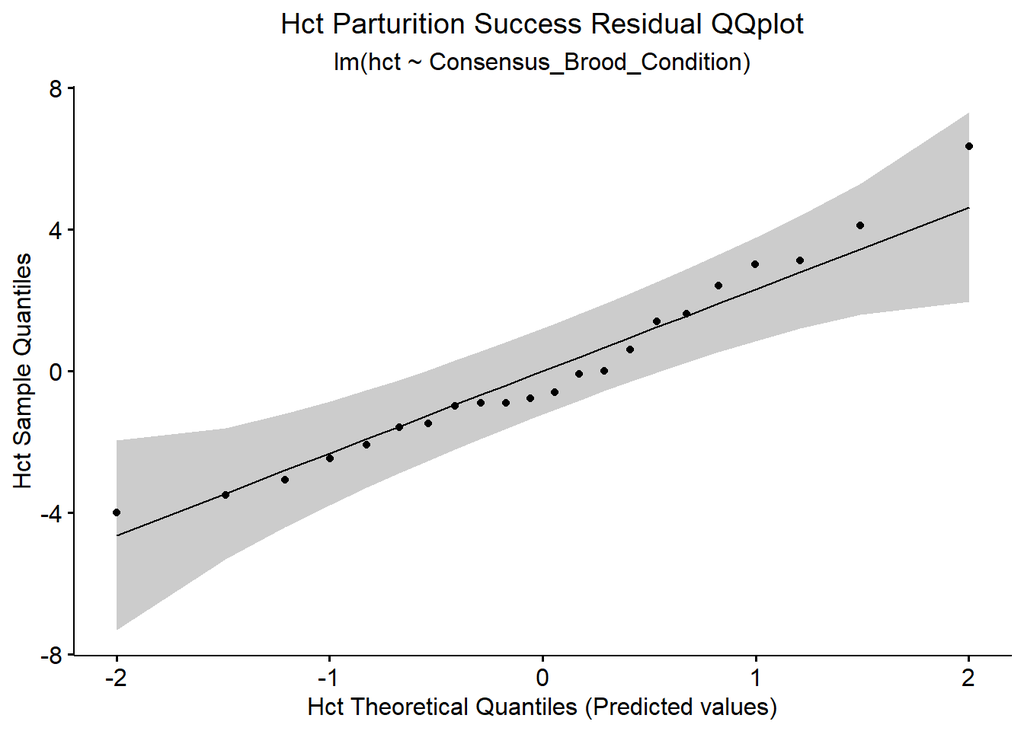

```r
# hct
# Parametric Assumptions

# Assessing Normality
# Normality Plots

# lm model of ambient data
hct_lm_ambient <- lm(Hct.... ~ Consensus_Brood_Condition, data = Ambient_Only_Samples)

# View all residual plots
#plot(hct_lm_ambient)

hct_res_ambient_qqplot <- ggqqplot(residuals(hct_lm_ambient)) +
labs(title = "Hct Parturition Success Residual QQplot",
     subtitle = "lm(hct ~ Consensus_Brood_Condition)",
                               x = "Hct Theoretical Quantiles (Predicted values)",
                               y = "Hct Sample Quantiles") +
  theme(plot.title = element_text(hjust = 0.5),
        plot.subtitle = element_text(hjust = 0.5))
print(hct_res_ambient_qqplot)
```

Review of Residual QQplot (normality conditions met?)

Ambient data:

Hct Parametric Assessment Testing Normality

```r
# hct
# Parametric Assumptions

# Assessing Normality

# Analytical Test: Options listed below
# - Shapiro Test = for piping, shapiro_test() or in base r shapiro.test(): normal distribution

# Note: Shapiro test is sensitive to sample size, small n often pass normality, so review both visuals and test results to assess if normality conditions are met or not

# Note Error Message: error in `shapiro.test()`: ! sample size must be between 3 and 5000

# Shapiro.test for General Samples
General_Samples %>% shapiro_test(Hct....)
```

```
## # A tibble: 1 × 3
##   variable statistic     p
##   <chr>        <dbl> <dbl>
## 1 Hct....      0.989 0.986
```

```r
General_Samples %>%
  group_by(Ambient.Or.OAH, Pregnant.Or.Atresia) %>%
  shapiro_test(Hct....)
```

```
## # A tibble: 4 × 5
##   Ambient.Or.OAH Pregnant.Or.Atresia variable statistic     p
##   <chr>          <chr>               <chr>        <dbl> <dbl>
## 1 Ambient        Atresia             Hct....      0.948 0.567
## 2 Ambient        Post Parturition    Hct....      0.950 0.694
## 3 OAH            Atresia             Hct....      0.906 0.444
## 4 OAH            Post Parturition    Hct....      0.983 0.752
```

```r
# Shapiro.test for Ambient Samples
Ambient_Only_Samples %>% shapiro_test(Hct....)
```

```
## # A tibble: 1 × 3
##   variable statistic     p
##   <chr>        <dbl> <dbl>
## 1 Hct....      0.976 0.851
```

```r
# Ambient_Only_Samples %>%
#   group_by(Consensus_Brood_Condition) %>%
#   shapiro_test(Hct....)
```

Review of Shapiro-Wilk test (normality conditions met?):

General data:

Ambient data:

Hct Parametric Assessment Testing Normality

```r
# hct
# Parametric Assumptions

# Assessing Normality

# Descriptive stat test: Stat.desc
# Z-score reflected in 'skew.2SE' and 'kurt.2SE'
# If these values are below 0.96 this indicates normality

# Note these values are sensitive to sample size, and are most effective for relatively small sample sizes approximately n = 30-50 range

# Note Alternative methods, all appear to display same results, not sure exactly how to incorporate an lm or aov model into the stat.desc function...

# General samples
General_Samples %>%
  summarise(Hct...., Ambient.Or.OAH, Pregnant.Or.Atresia) %>%
  stat.desc(norm = TRUE)
```

```
##                  Hct.... Ambient.Or.OAH Pregnant.Or.Atresia
## nbr.val       30.0000000             NA                  NA
## nbr.null       0.0000000             NA                  NA
## nbr.na         0.0000000             NA                  NA
## min            9.9000000             NA                  NA
## max           25.3000000             NA                  NA
## range         15.4000000             NA                  NA
## sum          523.1000000             NA                  NA
## median        17.2500000             NA                  NA
## mean          17.4366667             NA                  NA
## SE.mean        0.6491105             NA                  NA
## CI.mean.0.95   1.3275800             NA                  NA
## var           12.6403333             NA                  NA
## std.dev        3.5553246             NA                  NA
## coef.var       0.2038993             NA                  NA
## skewness       0.1848184             NA                  NA
## skew.2SE       0.2164695             NA                  NA
## kurtosis      -0.4461604             NA                  NA
## kurt.2SE      -0.2678852             NA                  NA
## normtest.W     0.9891380             NA                  NA
## normtest.p     0.9860613             NA                  NA
```

```r
# Ambient samples
Ambient_Only_Samples %>%
  summarise(Hct...., Brood_Condition) %>%
  stat.desc(norm = TRUE)
```

```
##                  Hct.... Brood_Condition
## nbr.val       22.0000000              NA
## nbr.null       0.0000000              NA
## nbr.na         0.0000000              NA
## min            9.9000000              NA
## max           22.3000000              NA
## range         12.4000000              NA
## sum          369.9000000              NA
## median        16.9500000              NA
## mean          16.8136364              NA
## SE.mean        0.6970965              NA
## CI.mean.0.95   1.4496915              NA
## var           10.6907576              NA
## std.dev        3.2696724              NA
## coef.var       0.1944655              NA
## skewness      -0.1288158              NA
## skew.2SE      -0.1311872              NA
## kurtosis      -0.8320434              NA
## kurt.2SE      -0.4366399              NA
## normtest.W     0.9763622              NA
## normtest.p     0.8507749              NA
```

Summary results of Hct distribution (normality criteria met?):

General data:

Ambient data:

Hct Parametric Assessment Assessing Scedasticity residual vs fitted plots

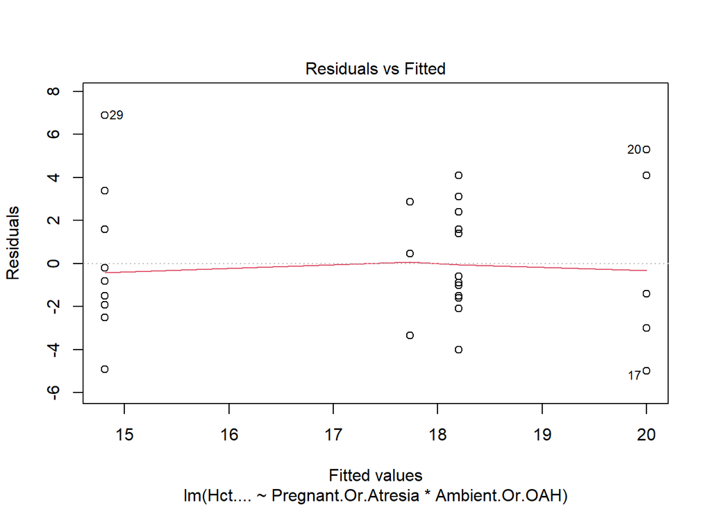

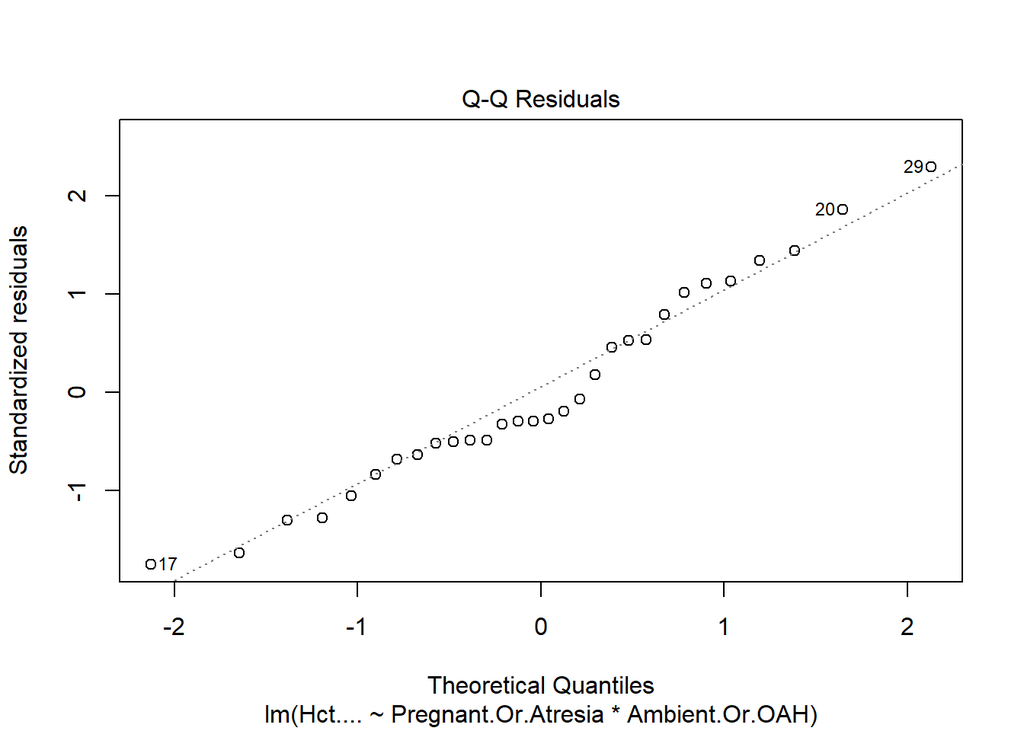

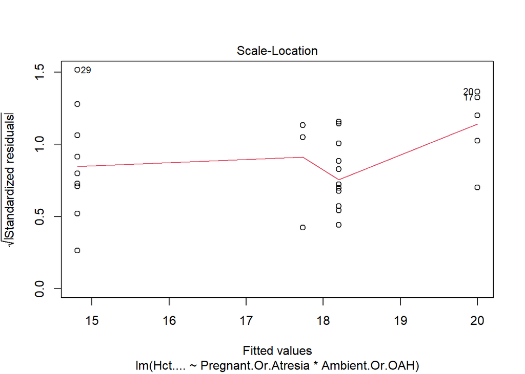

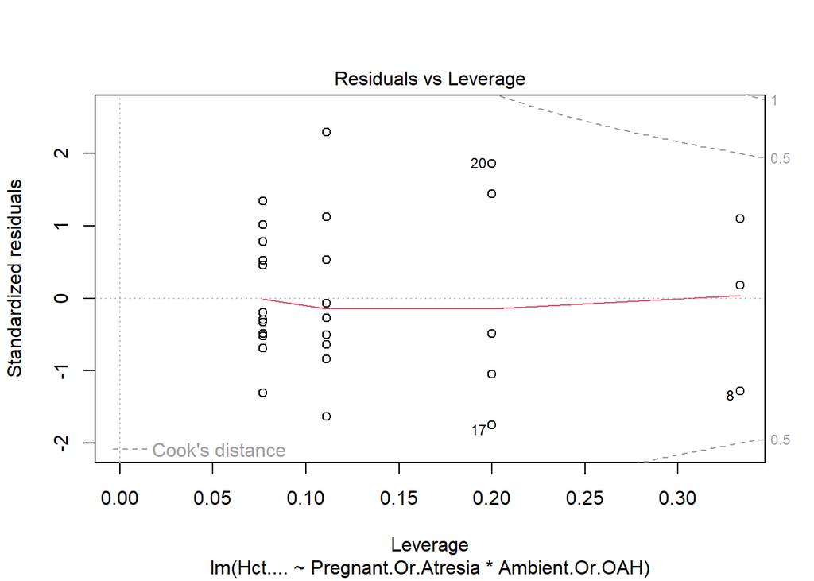

```r
# hct
# Parametric Assumptions
# Assessing Homoscedasticity: Equal Variance of Residuals

# Plotting residuals vs fitted

# Two-way ANOVA Interactive/Additive model: General factor comparison
lm(Hct.... ~ Pregnant.Or.Atresia * Ambient.Or.OAH, data = General_Samples) %>% plot()
```

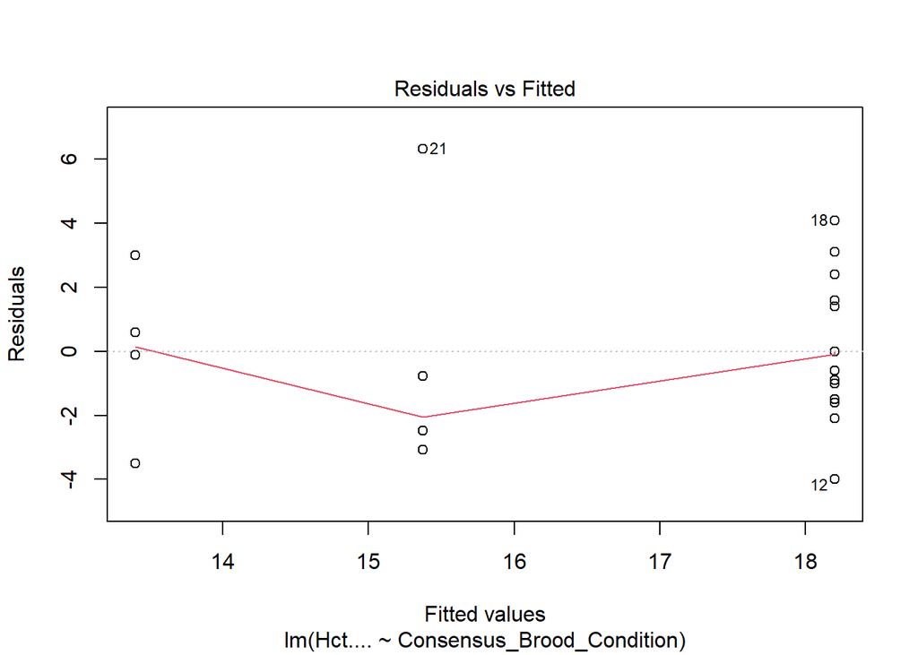

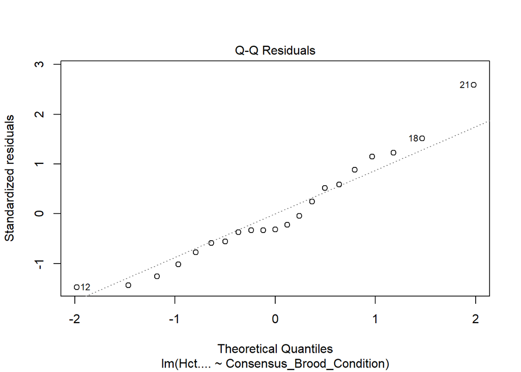

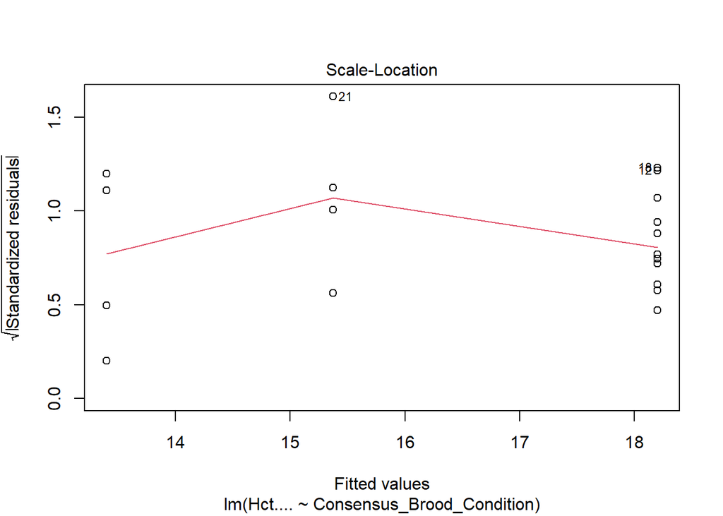

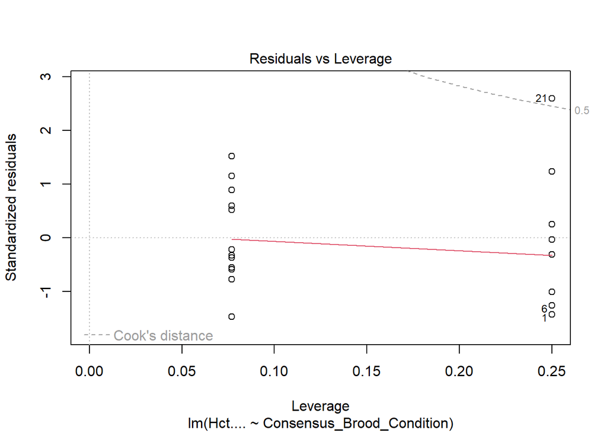

```r
# One-Way ANOVA model: Ambient Parturition Success comparison
lm(Hct.... ~ Consensus_Brood_Condition, data = Ambient_Only_Samples) %>%
plot()
```

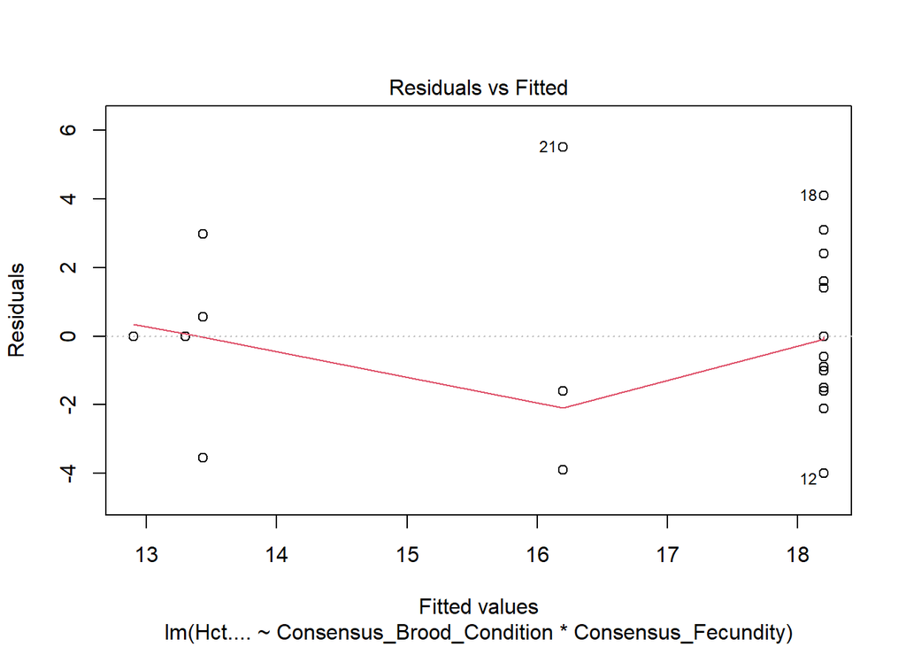

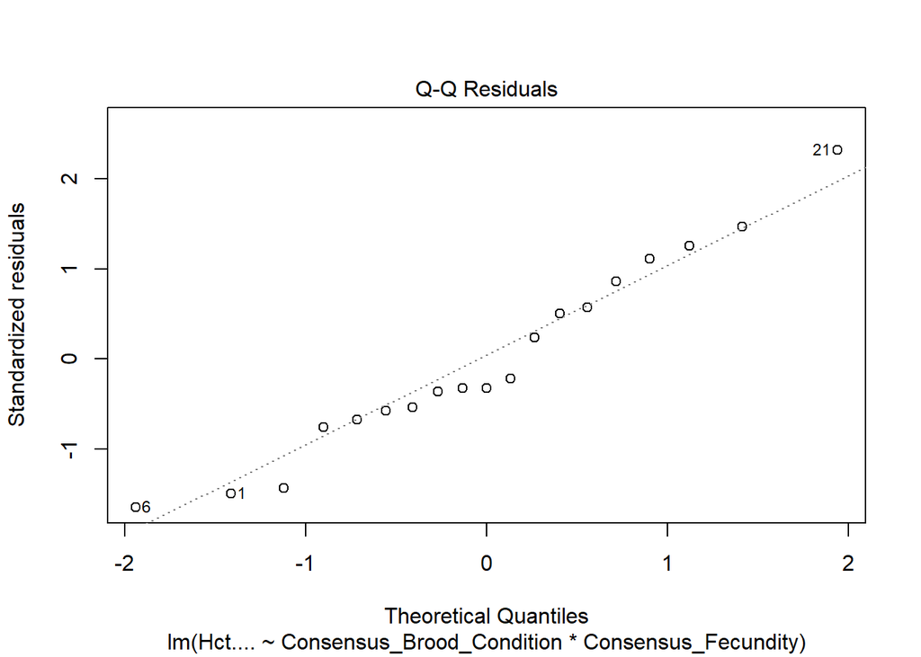

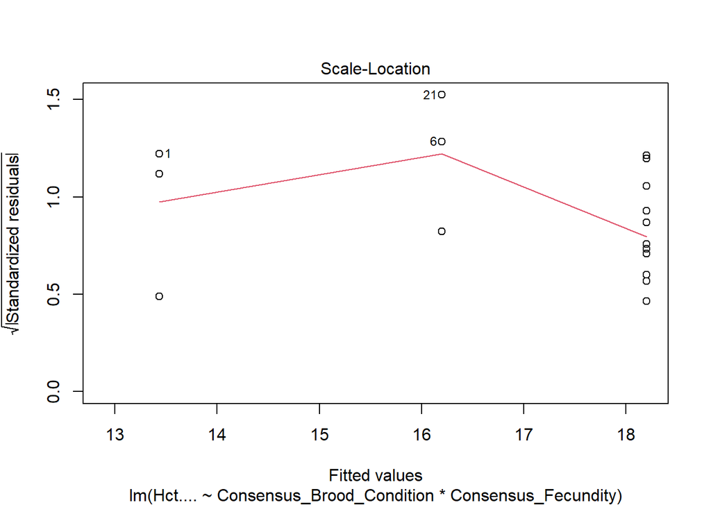

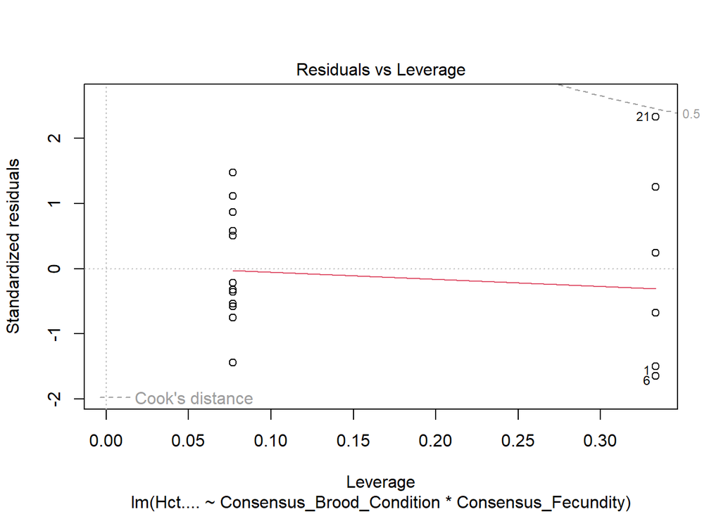

```r
# Exploratory investigations...
lm_ambient_fecund_int <- lm(Hct.... ~ Consensus_Brood_Condition * Consensus_Fecundity, data = Ambient_Only_Samples)
plot(lm_ambient_fecund_int)
```